# Statistique de la vitesse du vent

Haroun Al Mounayar

9 Avril 2021

Etant donnée des mesures de la vitesse du vent dans un lieu on cherche à savoir si on peut y construire une éolienne. Un lieu est convenable à la construction d’une éolienne si la vitesse moyenne du vent y est inférieur à 9m/s.

# 1 Analyse de la vitesse du vent

## Voir Code R

Les règles de Sturges donnent $k\simeq 1+log_2(100)\simeq 7.6 \simeq 8$. Pour avoir une idée visuelle de la loi traçons l’histogramme même si cela n’est pas demandé.

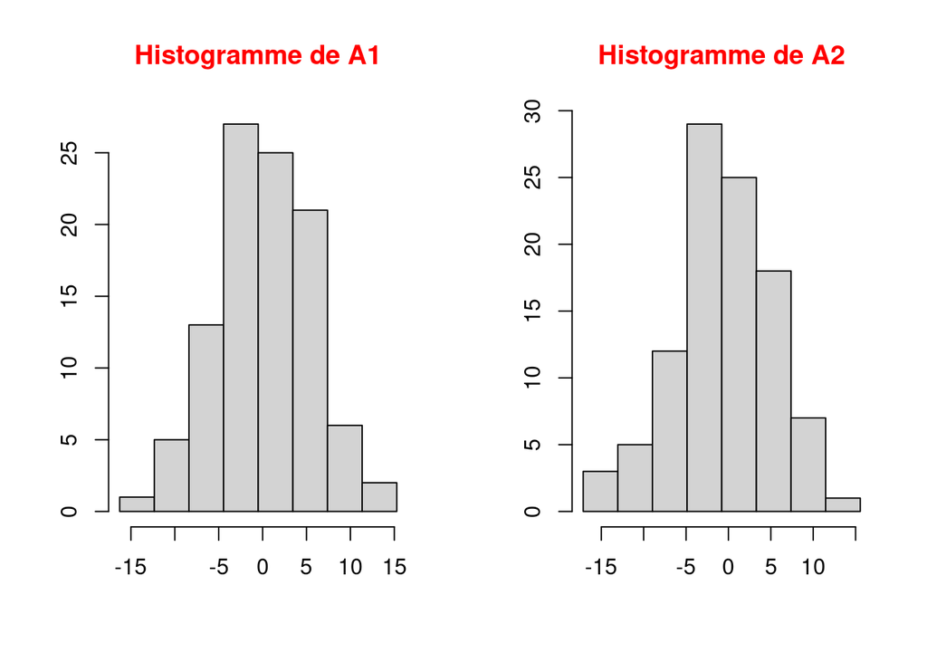

On remarque que ça possède l’allure d’une loi normale. Aussi, on remarque que la moyenne est proche de $0$ sur le graphe. Ainsi, l’hypothèse de l’énoncé de loi normale centrée semble cohérente avec les observations. En effet en physique des fluides, et sans contrainte physique imposée aux bords, Le milieu est isotrope, donc la vitesse du vents indépendante de la direction.

Pour s’assurer que $A_1$ et $A_2$ suivent une loi normale traçons le graphe de probabilité de la loi normale.

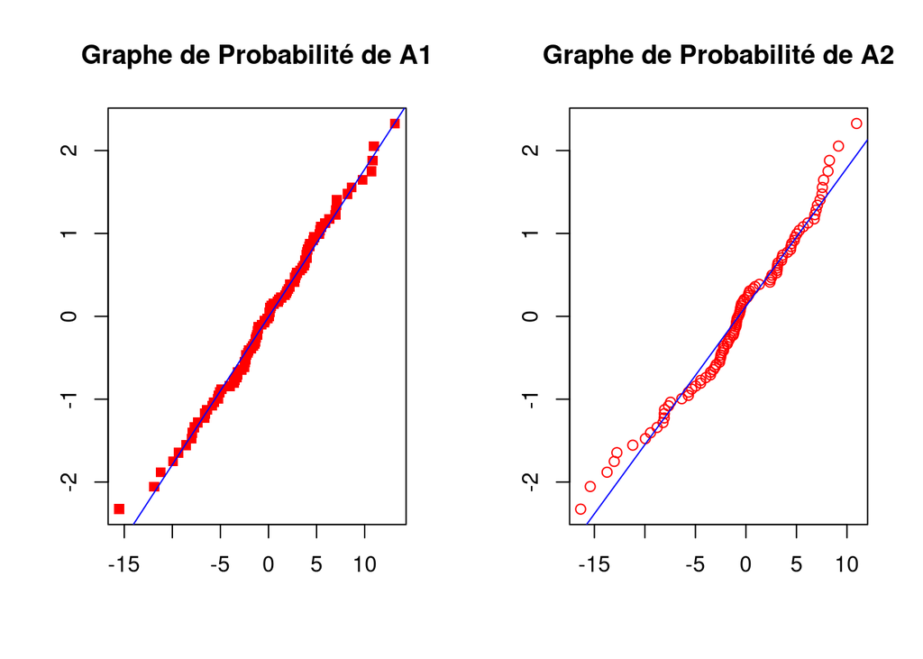

Une manière d’estimer $\sigma^2$ est de réunir les deux ensembles de points et de faire une régression linéaire.

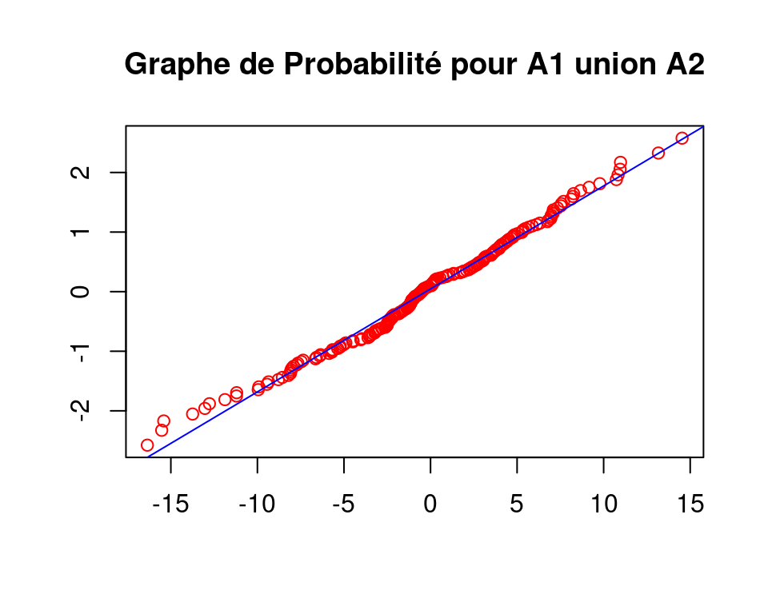

On estime alors :
$$\boxed{\sigma_{estim}^2=33.5}$$

## Voir Code R

Soit $i\in\{1,2\}$. On sait que $\frac{A_{i}}{\sigma}$ suit une loi normale centrée reduite. En effet $E[\frac{A_{i}}{\sigma}]=\frac{1}{\sigma}E[A_{i}]=0$ (car $E[A_{i}]=0$ et $Var(\frac{A_{i}}{\sigma})=\frac{Var(A_{i})}{\sigma^{2}}=1$.

Et vu que les $A_{i}$ sont indépendantes alors les $\frac{A_{i}}{\sigma}=U_{i}$ sont indépendants aussi. Or la somme du carrée de $n$ lois normales centrées réduites est une loi du $\chi^{2}$ a $n$ degrés de liberté.

Dans notre cas, on en déduit à partir du fait que $U_{1}^{2}+U_{2}^{2}=(\frac{A_{1}}{\sigma})^{2}+(\frac{A_{2}}{\sigma})^{2}=\frac{X^{2}}{\sigma^{2}}$ que $\frac{X^{2}}{\sigma^{2}}$ suit une loi du $\chi^{2}$ a deux dégrée de liberté qui n’est autre que la loi exponentielle de paramètre $\frac{1}{2}$

$$\boxed{\frac{X^{2}}{\sigma^{2}}\hookrightarrow\varepsilon(\frac{1}{2})}$$

Vérification expérimentale : on trace le graphe de probabilité de la loi exponentielle avec $\frac{X^{2}}{\sigma^{2}}$ .

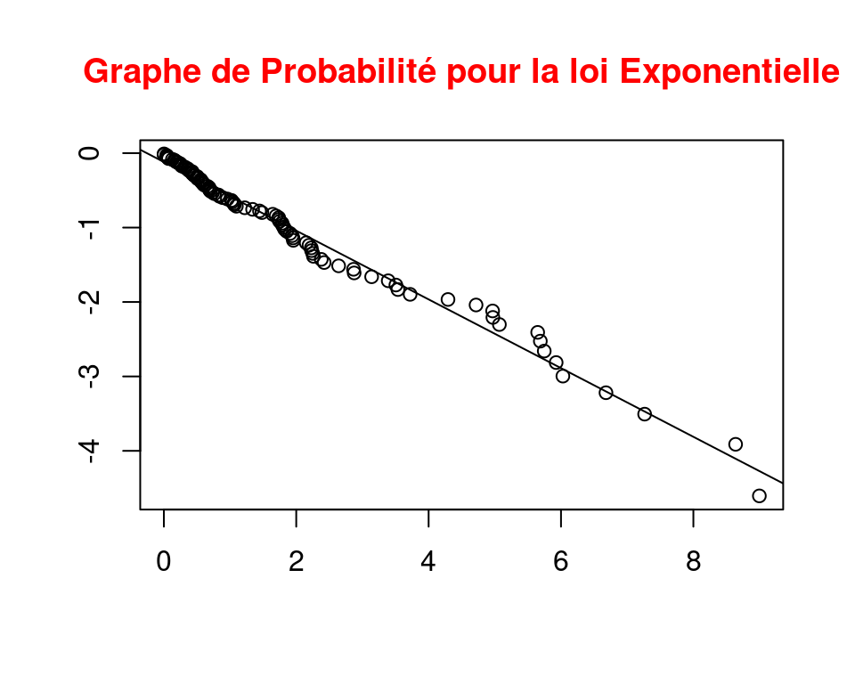

[output not shown]

```
## simulation[1:(n - 1)]
##             0.4615797
```

## 3

Soit $x\leq0$. Alors $P(X\leq x)=0$.

Soit maintenant $x>0$

On a $P(X\leq x)=P(\frac{X^{2}}{\sigma^{2}}\leq\frac{x^{2}}{\sigma^{2}})=\int_{0}^{x^{2}/\sigma^{2}}\frac{1}{2}e^{-\frac{1}{2}t}dt=[e^{-\frac{1}{2}t}]_{x^{2}/\sigma^{2}}^{0}=1-e^{-\frac{x^{2}}{2\sigma^{2}}}$.

La fonction de répartition de $X$ est donc :

$F:x\mapsto\begin{cases} 0 & \text{si }x\leq0\\ 1-e^{-\frac{x^{2}}{2\sigma^{2}}} & \text{si }x>0 \end{cases}$.

$F$ étant continue en $0$ ($F(0^{+})=F(0^{-})=0$) une densité existe. On dérive et on a directement le résultat.

La densité de X est donc :

$$\boxed{f_{X}:x\mapsto\frac{x}{\sigma^{2}}e^{-\frac{x^{2}}{2\sigma^{2}}}\boldsymbol{1}_{\mathbb{R}_{+}}(x)}$$

## Voir Code R

La fonction de répartition est pour $x>0$ : $F(x)=1-e^{-\frac{x^{2}}{2\sigma^{2}}}$.

On a donc $e^{-\frac{x^{2}}{2\sigma^{2}}}=1-F(x)$. On peut alors mettre cela sous la forme $-\frac{x^{2}}{2\sigma^{2}}=ln(1-F(x))$

On en déduit une expression du graphe de probabilité comme :

$$\boxed{\left(\frac{x_{i}^{*2}}{2},ln(1-\frac{i}{n})\right)\text{ avec \ensuremath{x_{i}^{*}} les valeurs de l'echantillon triées et \ensuremath{n} la taille de l'echantillon }}$$

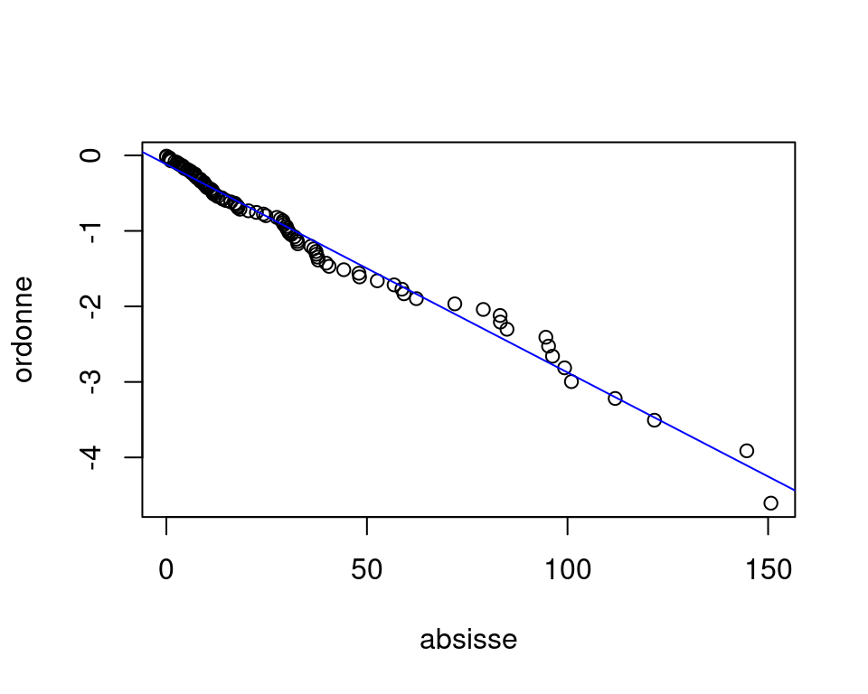

On en déduit donc en lisant la pente que :
$$\boxed{\sigma_{g}^2\simeq 36.288}$$
Cette valeur $36.288$ est proche de $33.5$ trouvée précédemment. Il reste à trouver quelle valeur est la meilleure.

## Voir Code R

On calcule $E[X]$ et $E[X^{2}]$ par la formule de transfert.

Ainsi,

$E[X]=\int_{0}^{+\infty}xf_{X}(x)dx=\int_{0}^{+\infty}x\frac{x}{\sigma^{2}}e^{-\frac{x^{2}}{2\sigma^{2}}}dx$. On fait une intégration par partie et on pose $u=x$ et $v'=\frac{x}{\sigma^{2}}e^{-\frac{x^{2}}{2\sigma^{2}}}$.

On a donc $E[X]=\left[-xe^{-\frac{x^{2}}{2\sigma^{2}}}\right]_{0}^{+\infty}+\int_{0}^{+\infty}e^{-\frac{x^{2}}{2\sigma^{2}}}dx=\frac{1}{2}\times\sqrt{\frac{\pi}{\frac{1}{2\sigma^{2}}}}=\frac{\sqrt{\pi}\sigma}{\sqrt{2}}$. (on utilise l’intégrale de Gauss) $\int_{-\infty}^{+\infty}e^{-\alpha x^{2}}dx=\sqrt{\frac{\pi}{\alpha}}$ le $\frac{1}{2}$ vient de la parité.

On a $E[X^{2}]=\int_{0}^{+\infty}x^{2}\frac{x}{\sigma^{2}}e^{-\frac{x^{2}}{2\sigma^{2}}}dx$. On fait une intégration par partie et on pose $u=x^{2}$ et $v'=\frac{x}{\sigma^{2}}e^{-\frac{x^{2}}{2\sigma^{2}}}$.

Il vient $E[X^{2}]=\int_{0}^{+\infty}x^{2}\frac{x}{\sigma^{2}}e^{-\frac{x^{2}}{2\sigma^{2}}}dx=\left[-x^{2}e^{-\frac{x^{2}}{2\sigma^{2}}}\right]_{0}^{+\infty}+\int_{0}^{+\infty}2xe^{-\frac{x^{2}}{2\sigma^{2}}}dx=\left[-2\sigma^{2}e^{-\frac{x^{2}}{2\sigma^{2}}}\right]_{0}^{+\infty}$

On obtient donc $E[X^{2}]=2\sigma^{2}$

On a donc $Var[X]=2\sigma^{2}-\frac{\pi}{2}\sigma^{2}$

$$\boxed{E[X]=\frac{\sqrt{\pi}\sigma}{\sqrt{2}}\text{ et }Var[X]=2\sigma^{2}-\frac{\pi}{2}\sigma^{2}}$$
Un estimateur de la variance de $X$ par la méthode des moments est la variance empirique $S_{n}^{2}=\frac{1}{n}\sum_{i=1}^{n}(X_{i}-\bar{X}_{n})^{2}=\frac{1}{n}\sum_{i=1}^{n}X_{i}^{2}-\bar{X}_{n}^{2}$

Montrons qu’il est biaisé $E[S_{n}^{2}]=E[\frac{1}{n}\sum_{i=1}^{n}X_{i}^{2}]-E[\bar{X}_{n}^{2}]=\frac{1}{n}\sum_{i=1}^{n}E[X_{i}^{2}]-E[\bar{X}_{n}^{2}]=E[X^{2}]-E[\bar{X}_{n}^{2}]$.

Avec l’expression de la variance et la loi des grands nombres, on a :

$E[S_{n}^{2}]=Var[X]+E[X]^{2}-Var[\bar{X}_{n}]-E[\bar{X}_{n}]^{2}=Var[X]+E[X]^{2}-\frac{Var[X]}{n}-E[X]^{2}=\frac{n-1}{n}Var[X].$

On a $E[S_{n}^{2}]\neq Var[X]$.

Un estimateur non biaisé est la variance estimée $S_{n}'^{2}=\frac{n}{n-1}S_{n}^{2}$

On en déduit $\sigma_{n}^{2}$ et $\sigma_{n}'^{2}$ en divisant respectivement $S_{n}^{2}$ et $S_{n}'^{2}$ par $(2-\frac{\pi}{2})$

On a donc :

$$\boxed{\sigma_{n}^{2}=\frac{\frac{1}{n}\sum_{i=1}^{n}X_{i}^{2}-\bar{X}_{n}^{2}}{2-\frac{\pi}{2}},\text{ et },\sigma_{n}'^{2}=\frac{n}{n-1}\frac{\frac{1}{n}\sum_{i=1}^{n}X_{i}^{2}-\bar{X}_{n}^{2}}{2-\frac{\pi}{2}}}$$
L’application numérique donne :
$$\boxed{\sigma_{n}^{2} \simeq 38.851, \text{ et },\sigma_{n}'^{2}\simeq39.243}$$

##Voir Code R Calculons un estimateur de max de vraissemblance pour $X$

La fonction de vraissemblance est $\mathcal{L}(x_{1},...,x_{n},\sigma^{2})=\prod_{i=1}^{n}f_{X_{i}}(x_{i},\sigma^{2})=\prod_{i=1}^{n}\frac{x_{i}}{\sigma^{2}}e^{-\frac{x_{i}^{2}}{2\sigma^{2}}}=e^{-\frac{1}{2\sigma^{2}}\sum_{i=1}^{n}x_{i}^{2}}\prod_{i=1}^{n}\frac{x_{i}}{\sigma^{2}}$

On prend le logarithme et on a $ln(\mathcal{L}(x_{1},...,x_{n},\sigma^{2}))=-\frac{1}{2\sigma^{2}}\sum_{i=1}^{n}x_{i}^{2}+\sum_{i=1}^{n}ln(x_{i})-nln(\sigma^{2})$

On derive et on a $\frac{\partial ln(\mathcal{L}(x_{1},...,x_{n},\sigma^{2}))}{\partial\sigma^{2}}=\frac{1}{(\sigma^{2})^{2}}\sum_{i=1}^{n}x_{i}^{2}-n\frac{2}{\sigma^{2}}$.

Cela donne l’EMV de la valeur de $\sigma^{2}$ en annulant la dérivée :
$$\boxed{\hat{\sigma}_{n}^{2}=\frac{1}{2n}\sum_{i=1}^{n}X_{i}^{2}}$$

L’application numérique donne :

$$\boxed{\hat{\sigma}_{n}^{2} \simeq 32.660}$$

```
## [1] 32.66009
```

Montrons que l’estimateur est sans biais et efficace.

Pour montrer que l’estimateur est sans biais, on calcule son espérance.

Ainsi, on calcule $E[\hat{\sigma}_{n}^{2}]=\frac{1}{2n}E[\sum_{i=1}^{n}X_{i}^{2}]=\frac{1}{2n}\sum_{i=1}^{n}E[X_{i}^{2}]=\frac{E[X^{2}]}{2}=\frac{2\sigma^{2}}{2}=\sigma^{2}$.

On en déduit donc que l’estimateur est sans biais.

Pour l’efficacité on calcule :

• $\mathcal{I}_{n}(\sigma^{2})=-E[\frac{\partial^{2}ln(\mathcal{L}(x_{1},...,x_{n},\sigma))}{(\partial\sigma^{2})^{2}}]=-\left(\frac{-1}{(\sigma^{2})^{3}}\sum_{i=1}^{n}E[X_{i}^{2}]+n\frac{1}{\sigma^{4}}\right)=\frac{+n}{(\sigma^{2})^{3}}2\sigma^{2}-n\frac{1}{\sigma^{4}}=\frac{n}{\sigma^{4}}$

• $Var[\hat{\sigma}_{n}^{2}]=\frac{1}{4n^{2}}\sum_{i=1}^{n}Var(X_{i}^{2})=\frac{1}{4n^{2}}\sum_{i=1}^{n}Var(\frac{X_{i}^{2}}{\sigma^{2}})\sigma^{4}$ Les $X_{i}$ étant de même loi on a : $Var[\hat{\sigma}_{n}^{2}]=\frac{1}{4n}Var(\frac{X^{2}}{\sigma^{2}})\sigma^{4}=\frac{\sigma^{4}}{n}$ ($\frac{X^{2}}{\sigma^{2}}$ est une loi exponentielle)

• $\frac{\partial E[\hat{\sigma}_{n}^{2}]}{\partial\sigma^{2}}=\frac{\partial\sigma^{2}}{\partial\sigma^{2}}=1$

On en déduit $Eff[\hat{\sigma}_{n}^{2}]=\frac{\left[\frac{\partial E[\hat{\sigma}_{n}^{2}]}{\partial\sigma^{2}}\right]^{2}}{\mathcal{I}_{n}(\sigma^{2})\times Var[\hat{\sigma}_{n}^{2}]}=\frac{1}{\frac{n}{\sigma^{4}}\times\frac{\sigma^{4}}{n}}=1$. L’estimateur est efficace.

$$\begin{tabular}{|c|c|}
\hline
Estimateur & Valeur\tabularnewline
\hline
\hline
Par regression lineaire de loi Normal & $\sigma_{N}^{2}=33.49484$\tabularnewline
\hline
Par regression lineaire de loi de Rayleigh & $\sigma_{g}^{2}=36.28843$ \tabularnewline
\hline
Methode des moments avec biais & $\widetilde{\sigma}_{n}^{2}=38.85148$\tabularnewline
\hline
Methode des moments sans biais & $\widetilde{\sigma'}_{n}^{2}=39.24392$\tabularnewline
\hline
Methode maximum de vraissemblance & $\hat{\sigma}_{n}^{2}=32.66009$\tabularnewline
\hline
\end{tabular}$$

On choisit l’ESBVM donc l’EMV (estimateur de max de vraissemblance). Il est efficace donc de variance minimale.

## Voir Code R

On a d’apres les questions précédentes $\frac{\sum_{i=1}^{n}X_{i}^{2}}{\sigma^{2}}=\sum_{i=1}^{n}\underbrace{\frac{A_{1,i}^{2}}{\sigma^{2}}}_{\hookrightarrow\mathcal{N}(0,1)}+\underbrace{\frac{A_{2,i}^{2}}{\sigma^{2}}}_{\hookrightarrow\mathcal{N}(0,1)}$. Or on sait que la somme du carré de $N$ variables aléatoires de loi $\mathcal{N}(0,1)$ indépendantes est une loi du $\chi_{N}^{2}$.

Dans notre cas, On note $F_{\chi_{2n}^{2}}$ la fonction de répartion de la loi $\chi_{2n}^{2}$

On choisit alors d’ecrire $F_{\chi_{2n}^{2}}(b)-F_{\chi_{2n}^{2}}(a)=1-\frac{\alpha}{2}-\frac{\alpha}{2}$.

Il vient avec les notation de la loi du $\chi^{2}$ , que $b=z_{2n,\alpha/2}$ et $a=z_{2n,1-\alpha/2}$.

On a donc l’intervalle de confiance $I$ au seuil $\alpha$ qui vaut:

$$\boxed{I=[\frac{\sum_{i=1}^{n}x_{i}^{2}}{z_{2n,\alpha/2}},\frac{\sum_{i=1}^{n}x_{i}^{2}}{z_{2n,1-\alpha/2}}]}$$

L’application numérique donne :
$$\boxed{I=[27.097, 40.140]}$$

## Voir Code R

L’important, c’est de ne pas payer de l’argent pour construire une éolienne et que celle-ci soit détruite à cause du vent. On aura payé pour rien, et mis des vies en danger. Le seuil du test est $\alpha$. C’est la probabilité de choisir l’hypothèse $H_{1}$ sachant que $H_{0}$ est vraie.

On prend donc $H_{0}:\mathbb{E}[X]\geq9$ et $H_{1}:\mathbb{E}[X]<9$. Ainsi en réduisant $\alpha$ on évite de supposer $\mathbb{E}[X]<9$ alors que $\mathbb{E}[X]\geq9$. Donc on évite de construire une éolienne et que celle-ci s’effondre sous l’action du vent.

On note $\hat{X}_{n}$ un estimateur de $\mathbb{E}[X]$. D’après la question 5, on sait que $\mathbb{E}[X]=\frac{\sigma\sqrt{\pi}}{\sqrt{2}}$. Ainsi on peut affirmer que :
$$\boxed{\hat{X}_{n}=\frac{\hat{\sigma}_{n}\sqrt{\pi}}{\sqrt{2}}}$$
avec $\hat{\sigma}_{n}$ l’EMV de $\sigma$.

On prend la forme de la région critique $W=\{\hat{X}_{n}\leq l_{\alpha}\}$

On calcule $\alpha=\underset{H_{0}}{Sup}P(\hat{X}_{n}<l_{\alpha})=\underset{\frac{\sigma\sqrt{\pi}}{\sqrt{2}}\geq9}{Sup}P\left(\frac{\hat{\sigma}_{n}\sqrt{\pi}}{\sqrt{2}}<l_{\alpha}\right)$. On élève au carré et on remplace $\hat{\sigma}_{n}$ par son expression et on a

$\alpha=\underset{\sigma\geq\frac{9\sqrt{2}}{\sqrt{\pi}}}{Sup}P\left(\sum_{i=1}^{n}X_{i}^{2}<l_{\alpha}^{2}\frac{4n}{\pi}\right)$. On divise par $\sigma^{2}$ pour obtenir $\frac{\sum_{i=1}^{n}X_{i}^{2}}{\sigma^{2}}\hookrightarrow\chi_{2n}^{2}$ (voir Q8). On note $F_{\chi_{2n}^{2}}$ la fonction de répartition de la loi $\chi_{2n}^{2}$.

On a donc $\alpha=\underset{\sigma\geq\frac{9\sqrt{2}}{\sqrt{\pi}}}{Sup}F_{\chi_{2n}^{2}}(l_{\alpha}^{2}\frac{4n}{\pi\sigma^{2}})=F_{\chi_{2n}^{2}}(l_{\alpha}^{2}\frac{2n}{81})$.

Avec les notations de la loi du $\chi^{2}$ on a $l_{\alpha}=\sqrt{\frac{81}{2n}z_{2n,1-\alpha}}$.

Ainsi :

On décide $H_{0}$ si les observation ne sont pas dans
$$\boxed{W=\{\hat{X}_{n}<\sqrt{\frac{81}{2n}z_{2n,1-\alpha}}\}}$$

Il vient donc :
$$\boxed{\alpha_{c}=F_{\chi_{2n}^{2}}(\frac{\hat{\sigma}_{n}^{2}\pi n}{81})}$$
L’application numérique donne

$$\boxed{\alpha_c\simeq1.277\times10^{-5}}$$

On prend alors comme valeur $\alpha= 1$%. Dans ce cas on a : - $\hat{X_{n}} \simeq 7.165$ - $l_\alpha=\sqrt{\frac{81}{2n}z_{2n,1-\alpha}}\simeq 7.959$

On est dans la région critique $W$. On rejette $H_0$ avec une confiance $1-\alpha$ de ne pas se tromper. On peut alors construire l’éolienne. Les risques de s’être trompé, c’est de construire l’éolienne et qu’elle soit détruite à cause d’une vitesse du vent trop grande.

# 2 Verifications experimentale a base de simulation

La fonction de répartition de X est donc :

$F:x\mapsto\begin{cases} 0 & \text{si }x\leq0\\ 1-e^{-\frac{x^{2}}{2\sigma^{2}}} & \text{si }x>0 \end{cases}$ (voir Q3)

Inversons $F$ pour $x>0$. On a $-\frac{x^{2}}{2\sigma^{2}}=ln(1-F(x))$. Donc $x=\sigma\sqrt{-2ln(1-F(x))}$.

On suppose qu’on possède un générateur de loi uniforme sur $[0,1]$ qu’on note $U$. Alors la variable $X=\sigma\sqrt{-2ln(1-U)}$ est de loi de Rayleigh de paramètre $\sigma$.

On peut même réécrire $X=\sigma\sqrt{-2ln(U)}$ car $1-U$ est aussi de loi uniforme sur $[0,1]$

Ainsi pour simuler $\mathcal{R}(\sigma^{2})$ :

• On simule $U$ uniforme sur $[0,1]$ avec notre générateur unifome

• On calcul $X=\sigma\sqrt{-2ln(U)}$

$X$ suit alors $\mathcal{R}(\sigma^2)$.

## Voir Code R

Pour bien présenter cette question sans simplement donner de code R brut et des résultats numériques, on a décidé de faire des graphes. Sur chaque graphe, on trace en noir la droite $y= 1-x$. Si un point se trouve sur la droite alors on a la proportion $p$ d’estimateur dans l’intervalle de confiance $IC$ qui vérifie $p=1-\alpha$. À chaque fois, on ne fait varier qu’un paramètre.

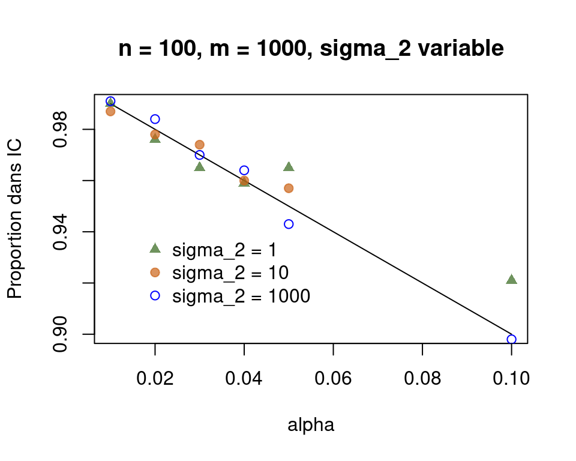

Dans ce graphe, on remarque que la distribution de point autour de la droite $y=1-x$ est aléatoire. La dépendance vis-à-vis de la valeur de $\sigma^2$ semble alors minime voir même inexistante.

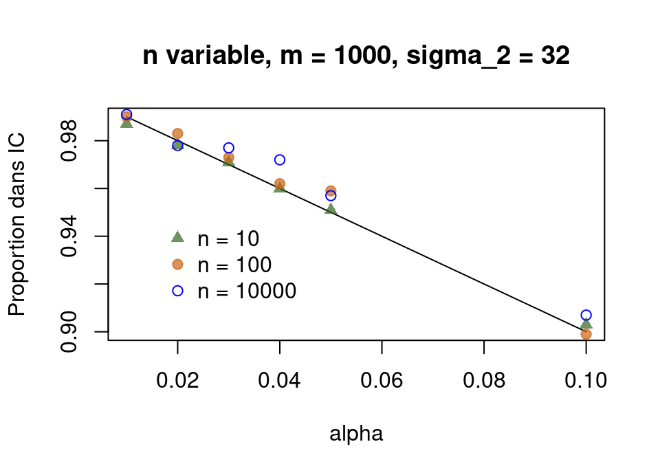

Si on fait varier $n$ on remarque que la distribution des points autour de la droite $y=1-x$ est aussi aléatoire. Donc la dépendance par rapport à $n$ semble elle aussi ne pas exister.

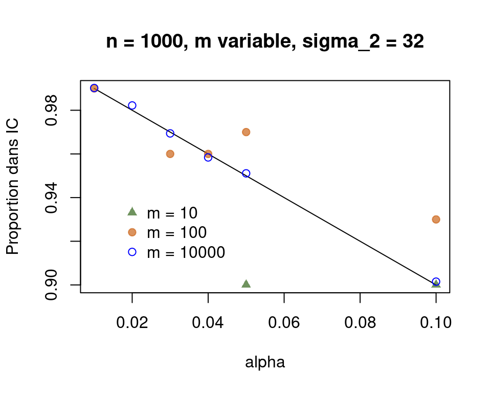

Si on fait varier $m$ on remarque une forte dépendance vis-à-vis de la distribution des points autour de la droite $y=1-x$. Si $m$ est grand, plus on simule d’estimateur, et plus la proportion d’estimateur dans l’intervalle de confiance est proche de $1-\alpha$, donc plus les points sont proches de la droite $y=1-x$. Pour $m$ petit, les points s’éloignent de la droite (des fois, ils ne sont pas visibles sur le schéma).

## Voir Code R

Sois $\sigma_{\text{estim}}^{2}$ un estimateur de $\sigma^{2}$.

Le biais est $E[\sigma_{\text{estim}}^{2}-\sigma^{2}]=E[\sigma_{\text{estim}}^{2}]-\sigma^{2}$. On fait alors la moyenne pour chacun des estimateurs sur ces m valeurs. On retranche $\sigma^{2}$ et on a le résultat.

L’EQM est $E[(\sigma_{\text{estim}}^{2}-\sigma^{2})^{2}]$. On retranche $\sigma^{2}$ , on élève au carré et on moyenne pour avoir le résultat.

On présente dans un tableau les résultats issus de simulations avec Rstudio avec $n=1000$, $m=10000$ et $\sigma^2=30$

$$\begin{tabular}{|c|c|c|c|}
\hline
Estimateur & Symbole & Biais & $EQM$\tabularnewline
\hline
\hline
Par regression lineaire de loi de Rayleigh & $\sigma_{g}^{2}$ & $-0.1944757$ & $1.681834$\tabularnewline
\hline
Methode maximum de vraissemblance & $\hat{\sigma}_{n}^{2}$ & $-0.008968043$ & $0.8921226$\tabularnewline
\hline
Methode des moments avec biais & $\widetilde{\sigma}_{n}^{2}$ & $-0.03750925$ & $2.019654$\tabularnewline
\hline
Methode des moments sans biais & $\widetilde{\sigma'}_{n}^{2}$ & $-0.007516762$ & $2.022346$\tabularnewline
\hline
\end{tabular}$$

Le meilleur estimateur est celui du maximum de vraisemblance. En effet, il est sans biais (biais proche de 0 dans les simulations) et il possède l’EQM la plus faible.

## Voir Code R

Pour notre exemple on choisi $T_{n}=\hat{\sigma}_{n}^{2}$. On fixe $m=1000$.

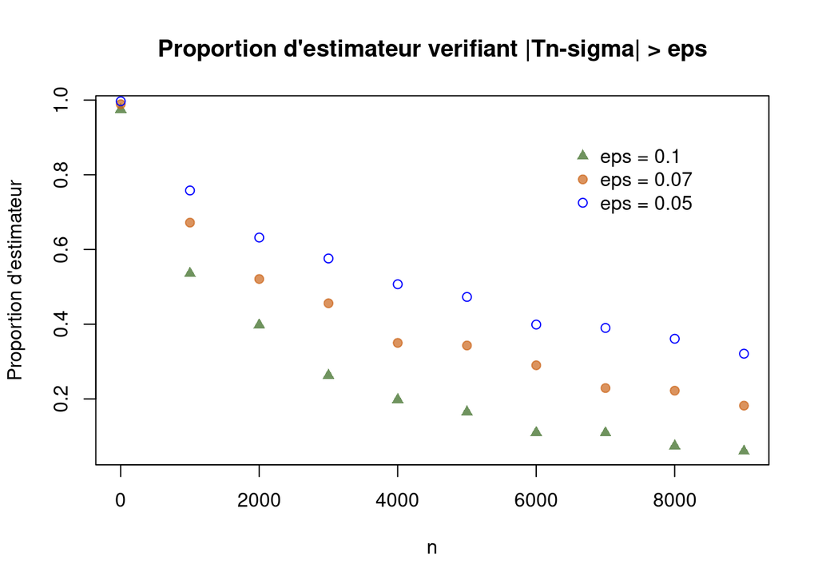

On remarque que pour les 3 valeurs de $\epsilon$ ca tend vers $0$ quand $n$ est grand. Et, si on diminue $\epsilon$ il faut un $n$ d’avantage plus grand pour converger vers la même valeur que si on n’avait pas diminuer $\epsilon$. La vitesse de convergence diminue quand $\epsilon$ diminue. Cela est parfaitement cohérent.

## Voir Code R

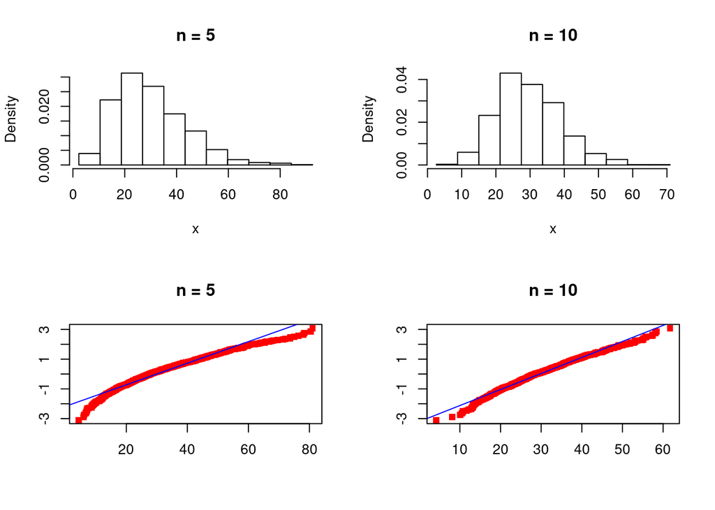

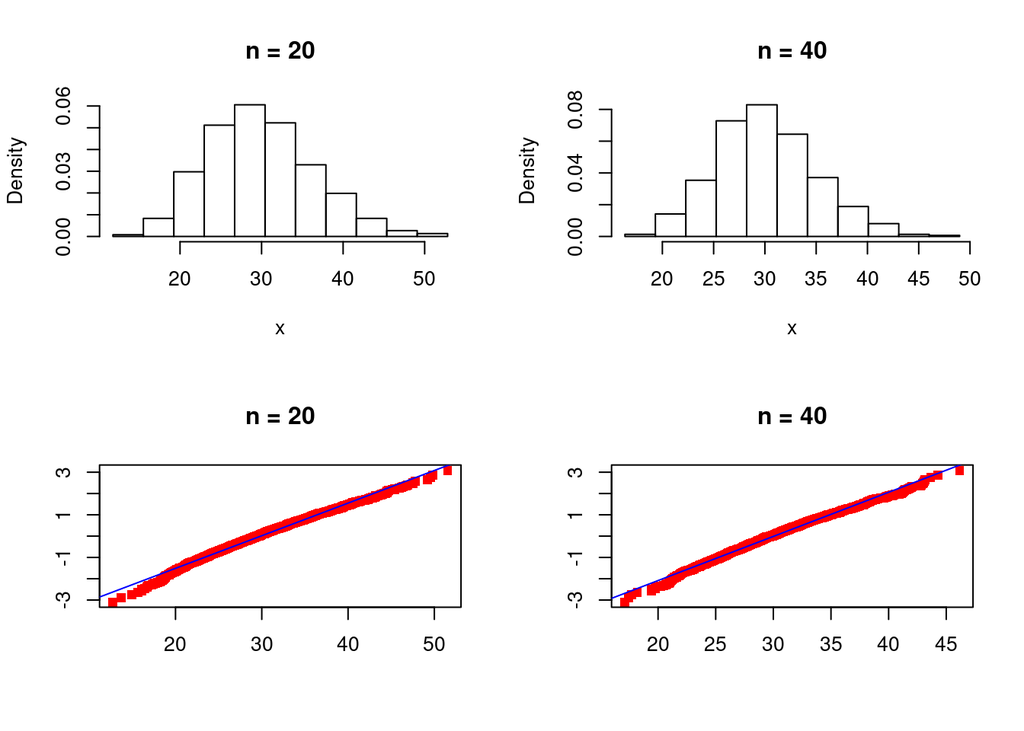

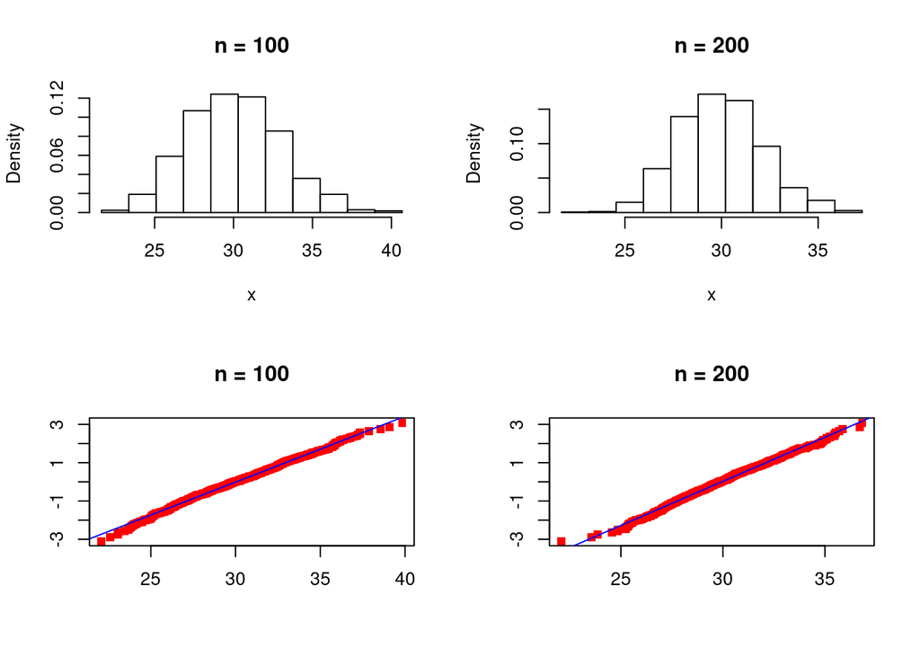

Pour des petites valeurs de $n$, les points ne sont visiblement pas alignés. On n’a pas une loi normale. Cependant, si on augmente $n$, le nuage de points dans $n=200$ par exemple, forme une droite. On a une loi normale. L’estimateur est donc normal asymptotiquement.

# Annexe code brute en R

```r
vent<-read.table("vent.csv",sep=";",header=T)
attach(vent)

par(mfcol=c(1,2))

#trace histo de A1
unsorted_A1 = as.numeric(unlist(vent[1]))
A1 <- sort(unsorted_A1)
n = length(A1)

a0<-A1[1]-0.025*(A1[n]-A1[1])
a7<-A1[n]+0.025*(A1[n]-A1[1])
h = (a7 - a0)/8

bornes_A1<-seq(a0,a7,h)
hist(A1, breaks=bornes_A1, main="Histogramme de A1", xlab='', ylab='',
     col.main="red")

#trace histo de A2
unsorted_A2 = as.numeric(unlist(vent[2]))
A2 <- sort(unsorted_A2)
n = length(A2)

a0<-A2[1]-0.025*(A2[n]-A2[1])
a7<-A2[n]+0.025*(A2[n]-A2[1])
h = (a7 - a0)/8

bornes_A2<-seq(a0,a7,h)
hist(A2, breaks=bornes_A2, main="Histogramme de A2", xlab='', ylab='',
     col.main="red")
```

```r
par(mfcol=c(1,2))
plot(A1[1:(n-1)], qnorm(seq(1:(n-1))/n), col = "red", pch = 15,
     main="Graphe de Probabilité de A1", xlab='',ylab='')

# On trace la droite de regression
reg_A1<-lm(qnorm(seq(1:(n-1))/n)~A1[1:(n-1)])
abline(reg_A1, col = "blue")

plot(A2[1:(n-1)], qnorm(seq(1:(n-1))/n), col = "red",
     main="Graphe de Probabilité de A2", xlab='',ylab='')


reg_A2<-lm(qnorm(seq(1:(n-1))/n)~A2[1:(n-1)])

abline(reg_A2, col = "blue")
```

```r
A1_A2 = sort(c(A1, A2))
n = length(A1_A2)

plot(A1_A2[1:(n-1)], qnorm(seq(1:(n-1))/n), col = "red",
     main="Graphe de Probabilité pour A1 union A2", xlab='', ylab='')

reg_A1_A2<-lm(qnorm(seq(1:(n-1))/n)~A1_A2[1:(n-1)])
# Calcul du paramètre
(1/reg_A1_A2$coefficients[2])^2

# On trace la droite de regression
abline(reg_A1_A2, col = "blue")
```

```r
sigma_squared = 33.5
simulation<-sort((unsorted_A1^2+unsorted_A2^2)/sigma_squared)
n = length(simulation)
plot(simulation[1:(n-1)], log(1-seq(1:(n-1))/(n)),
     main="Graphe de Probabilité pour la loi Exponentielle", col.main="red",
     xlab='', ylab='')

# On trace la droite de regression
reg_simu <- lm(log(1-seq(1:(n-1))/(n))~simulation[1:(n-1)])
abline(reg_simu)

# Lecture de Lambda
lambda <- -reg_simu$coefficients[2]
print("La valeur de lamda est: ", col="green")
print(lambda)
```

```r
X = sort(sqrt(unsorted_A1^2+unsorted_A2^2))
n = length(X)

ordonne = log(1-seq(1:(n-1))/n)
absisse = X[1:(n-1)]^2/2

plot(absisse, ordonne)

reg_X<-lm(ordonne~absisse)

# Calcul du paramètre
-(1/(reg_X$coefficients[2]))

abline(reg_X, col = "blue")
```

```r
n <- length(X)
S_n <- sum(X^2/n)-mean(X)^2

S_prime_n <- var(X)

sigma_n <- S_n/(2-pi/2)
sigma_prime_n <- S_prime_n/(2-pi/2)

sigma_n
sigma_prime_n
```

```r
n <- length(X)
sigmaChap_n <- sum(X^2/(2*n))
sigmaChap_n
```

```r
alpha = 0.05
n <- length(X)
somme_square = sum(X^2)
borne_inf = somme_square/qchisq(1-alpha/2, 2*n)
borne_sup = somme_square/qchisq(alpha/2, 2*n)
c(borne_inf, borne_sup)
```

```r
n <- length(X)
sigmaChap_n <- sum(X^2/(2*n))
temp <- sigmaChap_n*pi*n/81

alpha_c <- pchisq(temp, 2*n)

alpha_c
```

```r
X_chap_n <- sqrt(sigmaChap_n*pi/2)
X_chap_n

alpha=0.01
l_alpha <- sqrt(81/(2*n)*qchisq(alpha, 2*n))
l_alpha
```

```r
# Une fonction qui simule une loi de Rayleigh
simule_rayleigh <- function(taille, sigma_2) {
   uniforme <- runif(taille)
   rayleigh <- sqrt(sigma_2)*sqrt(-2*log(uniforme))
   return(rayleigh)
}

# Une fonction qui calcule l'intervalle de confiance IC
calcul_IC_sigma_2 <- function(Data, alpha) {
   n <- length(Data)
   somme_square = sum(Data^2)
   borne_inf = somme_square/qchisq(1-alpha/2, 2*n)
   borne_sup = somme_square/qchisq(alpha/2, 2*n)
   return(c(borne_inf, borne_sup))
}

# Fonction indicatrice de la presence dans l'IC
est_dansIC <- function(IC, valeur) {
   if (IC[1] < valeur & valeur < IC[2]) {
      return(1)
   }
   return(0)
}

# Fonction qui calcule la proportion d'estimateur dans IC
calcul_prop_ic <- function(alpha, sigma_2, n, m) {
   tot = 0
   for (i in 1:m) {
      data <- simule_rayleigh(n, sigma_2)
      ic <- calcul_IC_sigma_2(data, alpha)
      tot = tot + est_dansIC(ic, sigma_2)
   }
   return(tot/m)
}


# La suite est un simple tracé

liste_alpha <- c(0.01, 0.02, 0.03, 0.04, 0.05, 0.1)
liste_sigma_2 <- c(1, 10, 1000)
liste_n <- c(10, 100, 10000)
liste_m <- c(10, 100, 10000)


plot(liste_alpha, 1-liste_alpha, type="l", xlab="alpha",
     ylab="Proportion dans IC", main = "n = 100, m = 1000, sigma_2 variable")
for (i in 1:3) {
   ordonne <- c()
   for (j in 1:6) {
    ordonne[j] <- calcul_prop_ic(liste_alpha[j], liste_sigma_2[i], 100, 1000)
   }

   if (i == 1) {
   points(liste_alpha, ordonne, col=rgb(0.2,0.4,0.1,0.7), pch=17)
   }
   if (i == 2) {
   points(liste_alpha, ordonne, col=rgb(0.8,0.4,0.1,0.7), pch=19)
   }
   if (i == 3) {
   points(liste_alpha, ordonne, col="blue", pch=21)
   }
}
# Add a legend
legend("bottomleft",
  legend = c("sigma_2 = 1", "sigma_2 = 10", "sigma_2 = 1000"),
  col = c(rgb(0.2,0.4,0.1,0.7),
  rgb(0.8,0.4,0.1,0.7), "blue", "black"),
  pch = c(17,19, 21),
  bty = "n",
  pt.cex = 1,
  cex = 1,
  text.col = "black",
  horiz = F ,
  inset = c(0.1, 0.1))
```

```r
ordonne <- c()
plot(liste_alpha, 1-liste_alpha, type="l", xlab="alpha",
     ylab="Proportion dans IC", main = "n variable, m = 1000, sigma_2 = 32")
for (i in 1:3) {
   ordonne <- c()
   for (j in 1:6) {
    ordonne[j] <- calcul_prop_ic(liste_alpha[j], 32, liste_n[i], 1000)
   }

   if (i == 1) {
   points(liste_alpha, ordonne, col=rgb(0.2,0.4,0.1,0.7), pch=17)
   }
   if (i == 2) {
   points(liste_alpha, ordonne, col=rgb(0.8,0.4,0.1,0.7), pch=19)
   }
   if (i == 3) {
   points(liste_alpha, ordonne, col="blue", pch=21)
   }
}
# Add a legend
legend("bottomleft",
  legend = c("n = 10", "n = 100", "n = 10000"),
  col = c(rgb(0.2,0.4,0.1,0.7),
  rgb(0.8,0.4,0.1,0.7), "blue", "black"),
  pch = c(17,19, 21),
  bty = "n",
  pt.cex = 1,
  cex = 1,
  text.col = "black",
  horiz = F ,
  inset = c(0.1, 0.1))
```

```r
ordonne <- c()
plot(liste_alpha, 1-liste_alpha, type="l", xlab="alpha",
     ylab="Proportion dans IC", main = "n = 1000, m variable, sigma_2 = 32")
for (i in 1:3) {
   ordonne <- c()
   for (j in 1:6) {
    ordonne[j] <- calcul_prop_ic(liste_alpha[j], 32, 1000, liste_m[i])
   }

   if (i == 1) {
   points(liste_alpha, ordonne, col=rgb(0.2,0.4,0.1,0.7), pch=17)
   }
   if (i == 2) {
   points(liste_alpha, ordonne, col=rgb(0.8,0.4,0.1,0.7), pch=19)
   }
   if (i == 3) {
   points(liste_alpha, ordonne, col="blue", pch=21)
   }
}
# Add a legend
legend("bottomleft",
  legend = c("m = 10", "m = 100", "m = 10000"),
  col = c(rgb(0.2,0.4,0.1,0.7),
  rgb(0.8,0.4,0.1,0.7), "blue", "black"),
  pch = c(17,19, 21),
  bty = "n",
  pt.cex = 1,
  cex = 1,
  text.col = "black",
  horiz = F ,
  inset = c(0.1, 0.1))
```

```r
# Une fonction qui estime sigma^2 via une régression et la loi de Rayleigh
estim_sigmag_2 <- function(data) {
   n <- length(data)
   data <- sort(data)
   ordonne <- log(1-seq(1:(n-1))/n)
   absisse <- data[1:(n-1)]^2/2
   reg_d<-lm(ordonne~absisse)
   estim <- -(1/(reg_d$coefficients[2]))
   return(estim)
}

# Une fonction qui estime sigma^2 chapeau
estim_sigmaChap_2 <- function(data) {
   n <- length(data)
   return(sum(data^2/(2*n)))
}

# Une fonction qui estime sigma^2 tild
estim_sigmaTild_2 <- function(data) {
   n <- length(data)
   S_n <- sum(data^2/n)-mean(data)^2
   return(S_n/(2-pi/2))
}

# Une fonction qui estime sigma^2 tild prime
estim_sigmaTild_prime_2 <- function(data) {
   S_n <- var(data)
   return(S_n/(2-pi/2))
}

# Une fonction qui calcule le biais
calc_biais <- function(data, sigma_2) {
   n <- length(data)
   biais <- sum(data)/n - sigma_2
   return(biais)
}

# Une fonction qui calcule l'erreur quadratique moyenne
calc_EQM <- function(data, sigma_2) {
   n <- length(data)
   temp <- data - sigma_2
   eqm <- sum(temp^2/n)
   return(eqm)
}
```

```r
# La suites c'est des simples calculs

sigmag_2 = c()
sigmaChap_2 = c()
sigmaTild_2 = c()
sigmaTild_prime_2 = c()
sigma_2 = 30
n = 1000
m = 10000

for (i in 1:m) {
      data <- simule_rayleigh(n, sigma_2)
      sigmag_2[i] <- estim_sigmag_2(data)
      sigmaChap_2[i] <- estim_sigmaChap_2(data)
      sigmaTild_2[i] <- estim_sigmaTild_2(data)
      sigmaTild_prime_2[i] <- estim_sigmaTild_prime_2(data)
}

biais_sigmag_2 <- calc_biais(sigmag_2, sigma_2)
biais_sigmaChap2 <- calc_biais(sigmaChap_2, sigma_2)
biais_sigmaTild_2 <- calc_biais(sigmaTild_2, sigma_2)
biais_sigmaTild_prime_2 <- calc_biais(sigmaTild_prime_2, sigma_2)

eqm_sigmag_2 <- calc_EQM(sigmag_2, sigma_2)
eqm_sigmaChap2 <- calc_EQM(sigmaChap_2, sigma_2)
eqm_sigmaTild_2 <- calc_EQM(sigmaTild_2, sigma_2)
eqm_sigmaTild_prime_2 <- calc_EQM(sigmaTild_prime_2, sigma_2)

biais_sigmag_2
biais_sigmaChap2
biais_sigmaTild_2
biais_sigmaTild_prime_2

eqm_sigmag_2
eqm_sigmaChap2
eqm_sigmaTild_2
eqm_sigmaTild_prime_2
```

```r
# La fonction indicatrice qui vaut 1 si c'est supérieur à un epsilon
est_sup_a_EPS <- function(sigma_2, estimateur, eps) {
   if (abs(sigma_2-estimateur) > eps) {
      return(1)
   }
   return(0)
}

# Une fonction qui calcule la proportion voulue
calc_proportion <- function(eps, n, sigma_2, m) {
   tot = 0
   for (i in 1:m) {
      data <- simule_rayleigh(n, sigma_2)
      EMV <- estim_sigmaChap_2(data)
      tot = tot + est_sup_a_EPS(sigma_2, EMV, eps)
   }

   return(tot/m)
}

# La suite c'est des simples calculs et tracés

liste_eps <- c(0.1, 0.07, 0.05)
liste_n <- seq(1, 10000, 1000)
m = 1000
sigma_2 = 5

proba <- c()
for (j in 1:3) {
   for (i in 1:length(liste_n)) {
     proba[i] <- calc_proportion(liste_eps[j], liste_n[i], sigma_2, m)
   }
   if (j == 1) {
   plot(liste_n, proba, col=rgb(0.2,0.4,0.1,0.7), pch=17, xlab="n",
        ylab="Proportion d'estimateur",
        main="Proportion d'estimateur verifiant |Tn-sigma| > eps")
   }
   if (j == 2) {
   points(liste_n, proba, col=rgb(0.8,0.4,0.1,0.7), pch=19)
   }
   if (j == 3) {
   points(liste_n, proba, col="blue", pch=21)
   }
}
# Add a legend
legend("topright",
  legend = c("eps = 0.1", "eps = 0.07", "eps = 0.05"),
  col = c(rgb(0.2,0.4,0.1,0.7),
  rgb(0.8,0.4,0.1,0.7), "blue", "black"),
  pch = c(17,19, 21),
  bty = "n",
  pt.cex = 1,
  cex = 1,
  text.col = "black",
  horiz = F ,
  inset = c(0.1, 0.1))
```

```r
# La fonction qui trace un histogramme à classe de même largeur
histolarg <- function(x, xlim=NULL, col=NULL,...)
{
  # nombre de données
  n <- length(x)
  # nombre de classes (règle de Sturges)
  if (n<12) k<-5 else k <- round(log2(n)+1)
  # bornes des classes
  rangex <- max(x)-min(x)
  a0 <- min(x)-0.025*rangex
  ak <- max(x)+0.025*rangex
  bornes <- seq(a0, ak, length=k+1)
  # étendue du tracé
  if (is.null(xlim))
    xlim<-c(bornes[1], bornes[k+1])
  # histogramme
  histx<-hist(x, prob=T, col=col, breaks=bornes, xlim=xlim, ...)
  # histx
}


# Une fonction qui se charge de tout l'affichage graphique
trace_histo <- function(n, sigma_2, m, nom) {
   estimateur = c()
   for (i in 1:m) {
      data <- simule_rayleigh(n, sigma_2)
      estimateur[i] <- estim_sigmaChap_2(data)
   }
   estimateur <- sort(estimateur)
   histolarg(estimateur, main=nom)
   plot(estimateur[1:(m-1)], qnorm(seq(1:(m-1))/m), col = "red", pch = 15,
        main=nom, xlab='', ylab='')
   reg<-lm(qnorm(seq(1:(m-1))/m)~estimateur[1:(m-1)])
   abline(reg, col = "blue")

}
par(mfcol=c(2,2))
trace_histo(5, 30, 1000, "n = 5")
trace_histo(10, 30, 1000, "n = 10")
trace_histo(20, 30, 1000, "n = 20")
trace_histo(40, 30, 1000, "n = 40")
trace_histo(100, 30, 1000, "n = 100")
trace_histo(200, 30, 1000, "n = 200")
```